# 비모수 회귀모형 실습 과제

통계학 세미나

2019년 11월 29일까지 제출

이 과제에서는 **R** 라이브러리 `np`에 포함된 자료 `cps71`를 이용할 것이다. 자료 `cps71`는 1971 캐나다 통계청이 교육수주이 비슷한 205명의 남자들에 대한 나이(`age`)와 임금(로그로 변환 된 값, `logwage`) 자료이다.

**과제는 사용한 R 프로그램과 그림을 출력하여 제출하시오.**

```r
#install.packages("np")
library("np")
data("cps71")
head(cps71)
```

```
##   logwage age
## 1 11.1563  21
## 2 12.8131  22
## 3 13.0960  22
## 4 11.6952  22
## 5 11.5327  22
## 6 12.7657  22
```

### 문제 1.

나이(`age`)와 임금(`logwage`)에 대한 산포도를 그리시오.

### 문제 2.

나이(`age`)의 구간을 $(21,65)$으로 고려하자. 구간을 나누는 개수를 $k=5,10,15,20$으로 하여 임금(`logwage`)에 대한 regressogram을 그리시오.

### 문제 3.

나이(`age`)를 설명변수로 하여 임금(`logwage`)의 평균 함수를 정규분포 확률밀도함수를 이용한 커널 추정법으로 추정하려고 한다. CV를 최소로 하는 최적 구간의 길이 $h$ 를 구하시오.

### 문제 4.

문제 3 에서 구한 최적 구간의 길이 $h$를 이용하여 임금(`logwage`)의 커널 추정 함수와 95% 신뢰 구간을 그리시오.

### 문제 5.

앞에서 분석한 결과를 가지고 나이와 임금의 관계에 대하여 간략하게 설명하시오.

### 예제 프로그램

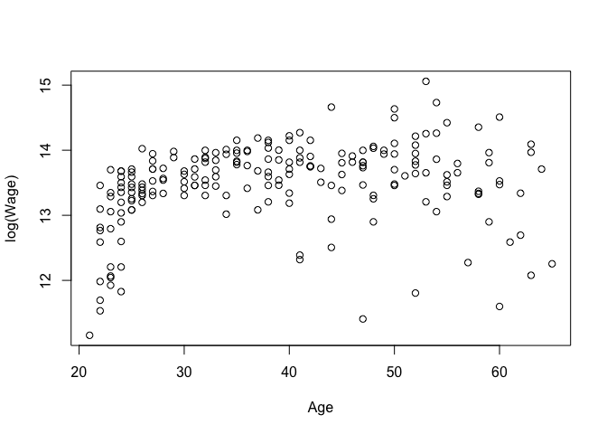

```r
plot(cps71$age, cps71$logwage, xlab="Age", ylab="log(Wage)")
```

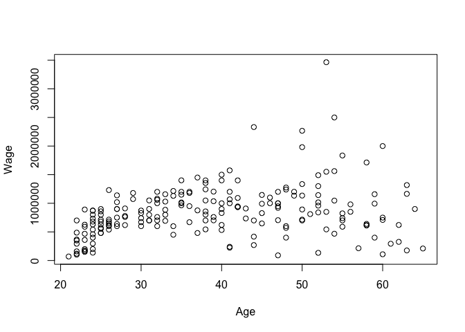

```r
plot(cps71$age, exp(cps71$logwage), xlab="Age", ylab="Wage")
```

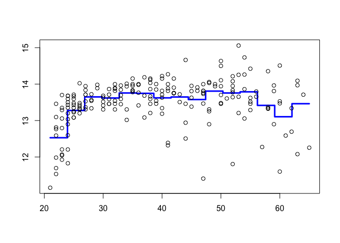

```r
regressogram = function(x,y,left,right,k,plotit,xlab="",ylab="",sub=""){
  ### assumes the data are on the interval [left,right]
  n = length(x)
  B = seq(left,right,length=k+1)
  WhichBin = findInterval(x,B)
  N = tabulate(WhichBin)
  m.hat = rep(0,k)
  for(j in 1:k){
    if(N[j]>0)m.hat[j] = mean(y[WhichBin == j])
  }
  if(plotit==TRUE){
    a = min(c(y,m.hat))
    b = max(c(y,m.hat))
    plot(B,c(m.hat,m.hat[k]),lwd=3,type="s",
         xlab=xlab,ylab=ylab,ylim=c(a,b),col="blue",sub=sub)
    points(x,y)
  }
  return(list(bins=B,m.hat=m.hat))
}

age = cps71$age
logwage = cps71$logwage
out = regressogram(age, logwage,left=21,right=65,k=15,plotit=TRUE)
```

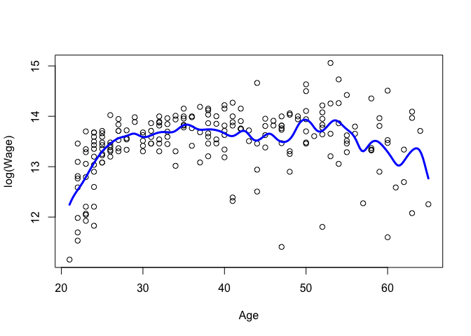

```r
kernel = function(x,y,grid,h){
  ### kernel regression estimator at a grid of values
  n = length(x)
  k = length(grid)
  m.hat = rep(0,k)
  for(i in 1:k){
    w = dnorm(grid[i],x,h)
    m.hat[i] = sum(y*w)/sum(w)
  }
  return(m.hat)
}
kernel.fitted = function(x,y,h){
  ### fitted values and diaginal of smoothing matrix
  n = length(x)
  m.hat = rep(0,n)
  S = rep(0,n)
  for(i in 1:n){
    w = dnorm(x[i],x,h)
    w = w/sum(w)
    m.hat[i] = sum(y*w)
    S[i] = w[i]
  }
  return(list(fitted=m.hat,S=S))
}


h=0.8
grid = seq(min(age),max(age),length=200)
m.hat = kernel(age, logwage,grid,h)
plot(age, logwage ,xlab="Age",ylab="log(Wage)")
lines(grid,m.hat,lwd=3,col="blue")
```